# Machine Learning Project

Charles L.

August 16, 2015

## Background

It is now possible to collect large amounts of data about human activity. Most of this has been in the form of quantitative exercise data. This project is based on qualitative data regarding one particular activity, lifting a dumbbell. Accelerators were placed on the belt, forearm, arm and dumbbell of 6 subjects. They then performed activities in the correct manner and 4 incorrect manners. The data was recorded for each. The goal of this project is to develop a model to predict the quality of the exercise as classified by A,B,C,D,E. “A”" being the correct manner. Cf. http://groupware.les.inf.puc-rio.br/har

## Executive Summary

Two models are developed. one is a decision tree, the other is a random forest. They are each subjected to cross validation. The random forest model is found to be far superior as judged by accuracy and out of sample error. It is this model that will be used for the submission section of this project.

## Project

**Download and read data, load libraries**

```r
#download raw data
# train_url <-'https://d396qusza40orc.cloudfront.net/predmachlearn/pml-training.csv'
# test_url <-'https://d396qusza40orc.cloudfront.net/predmachlearn/pml-testing.csv'
# download.file(train_url,destfile = "./training_data")
# download.file(test_url ,destfile = "./testing_data")
training <- read.table("./training_data",header = TRUE, sep = ",")
testing <- read.table("./testing_data",header = TRUE, sep = ",")
## load needed libraries:
suppressWarnings(suppressPackageStartupMessages(library(caret)))
suppressWarnings(suppressPackageStartupMessages(library(rpart)))
suppressWarnings(suppressPackageStartupMessages(library(RColorBrewer)))
suppressWarnings(suppressPackageStartupMessages(library(rattle)))
suppressWarnings(suppressPackageStartupMessages(library(rpart.plot)))
suppressWarnings(suppressPackageStartupMessages(library(randomForest)))
```

**Exploratory Data Analysis**  
Two data sets are downloaded `training` and `testing`. The second will not be used in this part of the project but only in the submission phase. The data is explored with `str()`, `summary()`, and `dim()`. The dimensions are shown.

```r
dim(training)
```

```
## [1] 19622   160
```

The `str()` and `summary()` functions reveal that a large percentage of the entries are `NA`(>20%). In addition the first several columns (7) contain things like names of subjects, time stamp etc. The last column contains the dependent variable “classe”. The results of these two functions are not shown in the interest of space.  
**Data Processing**  
First, the NA’s will be removed

```r
training<-training[,colSums(is.na(training)) == 0]
testing <-testing[,colSums(is.na(testing)) == 0]
```

Second, those numeric values close to zero variance are removed as they do not contribute to discrimination between the outcomes

```r
training<- training[ ,-nearZeroVar(training)]
testing <- testing[ ,-nearZeroVar(testing)]
```

Finally, the first seven columns are removed as described above

```r
training <- training[ ,-(1:7)]
tesing <- testing[ ,-(1:7)]
```

The final dimensions are as follows. There are 51 independent and 1 dependent variables.

```r
dim(training)
```

```
## [1] 19622    52
```

**Partitioning**  
The training set is divided in to a set for training and a set for cross validation on a 75/25 basis. These will be used for model raining and validation.

```r
set.seed(666)
trainIndex <- createDataPartition(y=training$classe, p=0.75)[[1]]
train1 <- training[trainIndex,]
train_valid <- training[-trainIndex,]
```

# Classification Tree Model

The first model is a classification Tree which follows with the statistics.

```r
fitTree <- train(classe ~.,data = train1, method = "rpart")
fitTree$finalModel
```

```
## n= 14718
##
## node), split, n, loss, yval, (yprob)
##       * denotes terminal node
##
##  1) root 14718 10533 A (0.28 0.19 0.17 0.16 0.18)
##    2) pitch_forearm< -33.95 1185     6 A (0.99 0.0051 0 0 0) *
##    3) pitch_forearm>=-33.95 13533 10527 A (0.22 0.21 0.19 0.18 0.2)
##      6) accel_belt_z>=-186.5 12737  9741 A (0.24 0.22 0.2 0.19 0.15)
##       12) magnet_dumbbell_y< 426.5 10475  7570 A (0.28 0.17 0.23 0.19 0.13)
##         24) roll_forearm< 123.5 6535  3939 A (0.4 0.17 0.18 0.16 0.092) *
##         25) roll_forearm>=123.5 3940  2643 C (0.078 0.17 0.33 0.23 0.19)
##           50) accel_forearm_x>=-101.5 2713  1698 C (0.089 0.21 0.37 0.1 0.23) *
##           51) accel_forearm_x< -101.5 1227   595 D (0.055 0.092 0.23 0.52 0.11) *
##       13) magnet_dumbbell_y>=426.5 2262  1233 B (0.04 0.45 0.048 0.2 0.26) *
##      7) accel_belt_z< -186.5 796    10 E (0.013 0 0 0 0.99) *
```

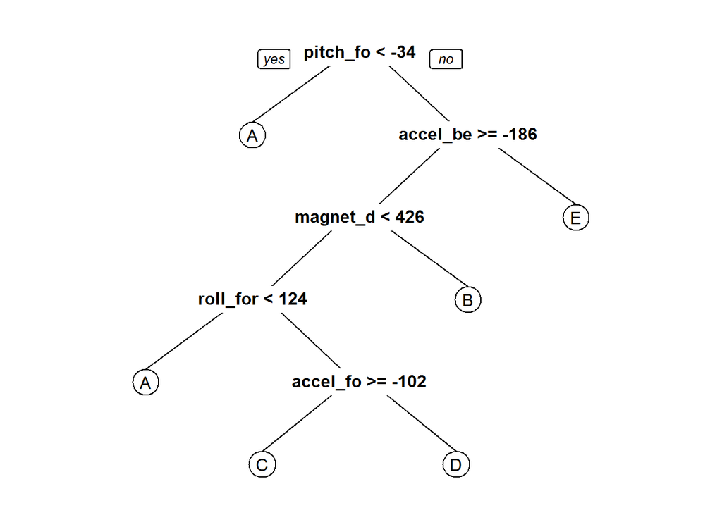

```r
prp(fitTree$finalModel)
```

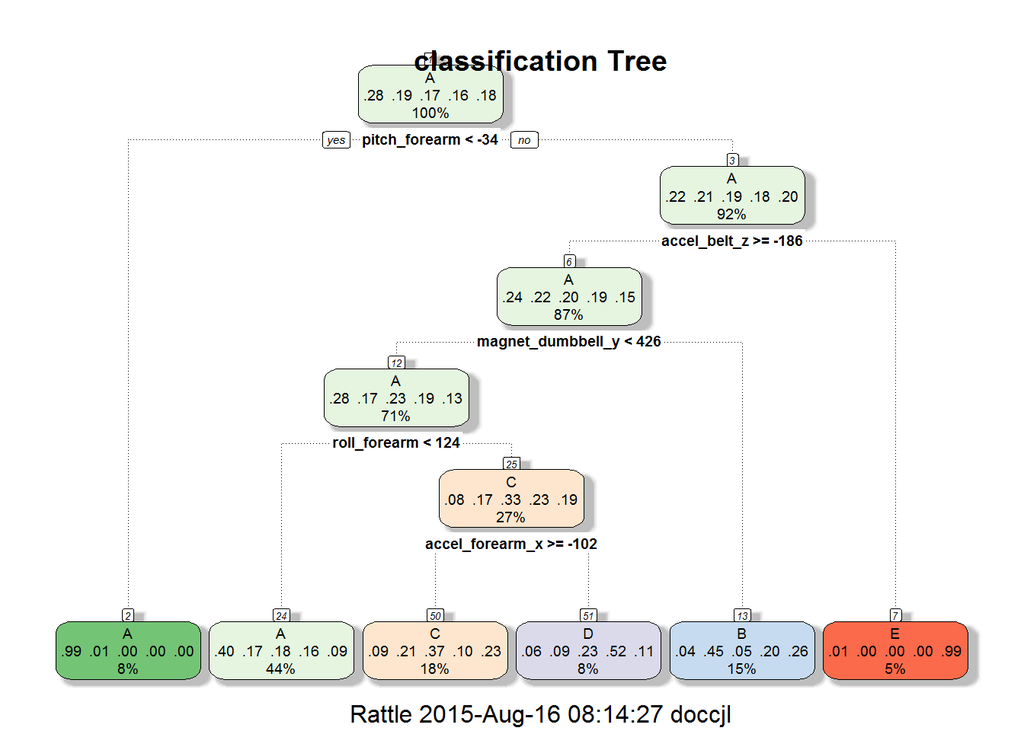

```r
fancyRpartPlot(fitTree$finalModel, main = "classification Tree")
```

**Statistics**(the model `fitTree` is validated with the set `train_valid)

```r
predictions <-predict(fitTree, newdata = train_valid[ ,-52])
confusionMatrix(predictions, train_valid$classe)
```

```
## Confusion Matrix and Statistics
##
##           Reference
## Prediction    A    B    C    D    E
##          A 1270  394  407  381  206
##          B   32  319   21  160  192
##          C   71  199  340   95  209
##          D   16   36   87  168   40
##          E    6    1    0    0  254
##
## Overall Statistics
##
##                Accuracy : 0.4794
##                  95% CI : (0.4653, 0.4935)
##     No Information Rate : 0.2845
##     P-Value [Acc > NIR] : < 2.2e-16
##
##                   Kappa : 0.318
##  Mcnemar's Test P-Value : < 2.2e-16
##
## Statistics by Class:
##
##                      Class: A Class: B Class: C Class: D Class: E
## Sensitivity            0.9104  0.33614  0.39766  0.20896  0.28191
## Specificity            0.6044  0.89760  0.85824  0.95634  0.99825
## Pos Pred Value         0.4778  0.44061  0.37199  0.48415  0.97318
## Neg Pred Value         0.9443  0.84928  0.87093  0.86043  0.86065
## Prevalence             0.2845  0.19352  0.17435  0.16395  0.18373
## Detection Rate         0.2590  0.06505  0.06933  0.03426  0.05179
## Detection Prevalence   0.5420  0.14763  0.18638  0.07076  0.05322
## Balanced Accuracy      0.7574  0.61687  0.62795  0.58265  0.64008
```

**Evaluation**  
This model does not use much computer resources (31 sec to train), but does not perform well. It has an accuracy of only **48%**. Using the formula $1-accuaracy$, the out of sample error rate is **52%. The classification tree has therefore minimal use.

# Random Forest Model

The second model is a Random Forest. The model and statistics follow,

```r
forestModel <- train(classe ~.,data=train1, method = "rf")
forestModel$finalModel
```

```
##
## Call:
##  randomForest(x = x, y = y, mtry = param$mtry)
##                Type of random forest: classification
##                      Number of trees: 500
## No. of variables tried at each split: 26
##
##         OOB estimate of  error rate: 0.57%
## Confusion matrix:
##      A    B    C    D    E  class.error
## A 4183    1    0    0    1 0.0004778973
## B   18 2822    6    2    0 0.0091292135
## C    0   11 2550    6    0 0.0066225166
## D    0    0   21 2386    5 0.0107794362
## E    0    0    4    9 2693 0.0048041390
```

**Statistics**

```r
predictionsRf <- predict(forestModel, newdata = train_valid[ ,-52])
confusionMatrix(predictionsRf, train_valid$classe)
```

```
## Confusion Matrix and Statistics
##
##           Reference
## Prediction    A    B    C    D    E
##          A 1394    8    0    0    0
##          B    1  940    2    0    0
##          C    0    0  852    4    0
##          D    0    0    1  799    4
##          E    0    1    0    1  897
##
## Overall Statistics
##
##                Accuracy : 0.9955
##                  95% CI : (0.9932, 0.9972)
##     No Information Rate : 0.2845
##     P-Value [Acc > NIR] : < 2.2e-16
##
##                   Kappa : 0.9943
##  Mcnemar's Test P-Value : NA
##
## Statistics by Class:
##
##                      Class: A Class: B Class: C Class: D Class: E
## Sensitivity            0.9993   0.9905   0.9965   0.9938   0.9956
## Specificity            0.9977   0.9992   0.9990   0.9988   0.9995
## Pos Pred Value         0.9943   0.9968   0.9953   0.9938   0.9978
## Neg Pred Value         0.9997   0.9977   0.9993   0.9988   0.9990
## Prevalence             0.2845   0.1935   0.1743   0.1639   0.1837
## Detection Rate         0.2843   0.1917   0.1737   0.1629   0.1829
## Detection Prevalence   0.2859   0.1923   0.1746   0.1639   0.1833
## Balanced Accuracy      0.9985   0.9949   0.9978   0.9963   0.9975
```

**Evaluation**  
This model is much more demanding on computer resources than the previous one (1hr 32 min. to train). It is, however, much more accurate with an accuracy of **99.55%**. Using the same formula $1-accuracy$, this gives us an out of sample error rate of **0.45%**.

## Appendix

**Submission** The following code will be used in the submission section of the project.

```r
predictSubm <- predict(forestModel, newdata = testing)
answer <- as.character(predictSubm)
answer
```

```
##  [1] "B" "A" "B" "A" "A" "E" "D" "B" "A" "A" "B" "C" "B" "A" "E" "E" "A"
## [18] "B" "B" "B"
```

[output not shown]